# Minds bending Space and Time

Sameer Kolluri (ssk2258)

# Introduction

The study of philosophy has given us many schools of thought by which we can choose to govern our lives. The greatest thinkers throughout time have attempted to provide society a logically consistent framework in which to lead a life. As one surveys the course the history of humanity has taken, it is only natural for the study of the “love for wisdom” to have been birthed. It is a commonly recorded bias for humans to look for patterns in chaos, and the reasons for existence to humankind are remain the biggest mysteries still pursued. Many have thought of novel frameworks to operate and live within. In many cases, the thought process and reasoning for a school of though were later expanded upon by other thinkers who believed in the same rationale, but were separated by time and/or space. It can be observed that contributions to certain schools, such as feminism and analytic philosophy, happen over longer decades if not centuries, so it is interesting to think how the beliefs were maintained or even updated over time. I find this to be an interesting and special pattern of human history, where two people can experience vastly different lives, yet arrive at similar conclusions or frames of mind. What does it take for such connections to occur? Are these unique situations or is there an ability to explain these parallels? In the following analysis, I dive deeper into the data.

For this study, I am using the Philosophy Data Project’s data set, available on [Kaggle](https://www.kaggle.com/datasets/kouroshalizadeh/history-of-philosophy).

The schools of thought to be considered and their authors are shown in the below sections. Aside from Plato, Aristotle, and Nietzsche, whose schools are fully derived from their work, the remaining schools: Empiricism, Rationalism, Analytic, Continental, Phenomenology, German Idealism, Communism, Capitalism, Stoicism, and Feminism all have a couple contributors shown here. However, many of this subset were written about in close proximity. I would like to expand my analysis to schools that span a greater time horizon and so, the follow analysis will be on feminism and analytic philosophy. I will call the first author of a school’s text as the original and compare the rest of the cohort to them. I also will look at an author’s work on aggregate; their first text is no more a part of the body of their work than their last text.

Namely, I believe there will be interesting findings about the similarities of these thinkers within the respective schools. With respect to feminism, the movement is a fairly modern one, but history is full of stories of women continually breaking societal barriers and advancing equality. The interesting part of this data set is the wide gap between its first and most recent feminists. I believe a bridge can be built to connect those women, despite differences in time, geography and race. As analytical philosophy is discussed, while the mobility of the proponents was greatly increased as it is more of a modern phenomenon as well, to say the thinkers share Western thinking is inaccurate. Moore and Russell had as much in common with Kripke as Wollstonecraft had with Davis. Still, all these men to discussed later share a certain curiosity for knowledge bred by their own experiences that brought them along the same path.

The following analysis follows a pattern in constructing the story. In both cases, I am trying to ascertain as much knowledge from the style of writing as much as the content. That is, I observe the length of sentences and identify and trends there. After that, I look at the most emotionally charged statements each writer makes. In conjunction with a word cloud, which allows me to see the most occurring words in each author’s texts, I develop a full picture about the writer’s motivations and issues and discuss the connections they share with their colleagues.

# Feminism

| author | first_writing_year |
| --- | --- |
| Wollstonecraft | 1792 |
| Beauvoir | 1949 |
| Davis | 1981 |

An interesting aspect about the feminist movement is the first text was written in 1792. It took 150 years for the next text in this data set to come out. One confounding factor is these thinkers were from different parts of the world: Wollstonecraft from Britain, Beauvoir from France and Davis from the US. Nevertheless, the movements seem to share some similarities.

The chart below stood out to me quite a bit till I did some research. The shape of the beeswarm has some interesting properties. While Wollstonecraft was the first and addressed serious issues with the social structure, Beauvoir came from a bourgeois family that, despite financial setbacks, insisted on her receiving proper education. This most likely led to greater writing skills and literary capacity. Davis, who lived in the segregated South, while attaining higher levels of education, was significantly influenced by real-world politics and classism and was most likely able to keep her writings accessible for most.

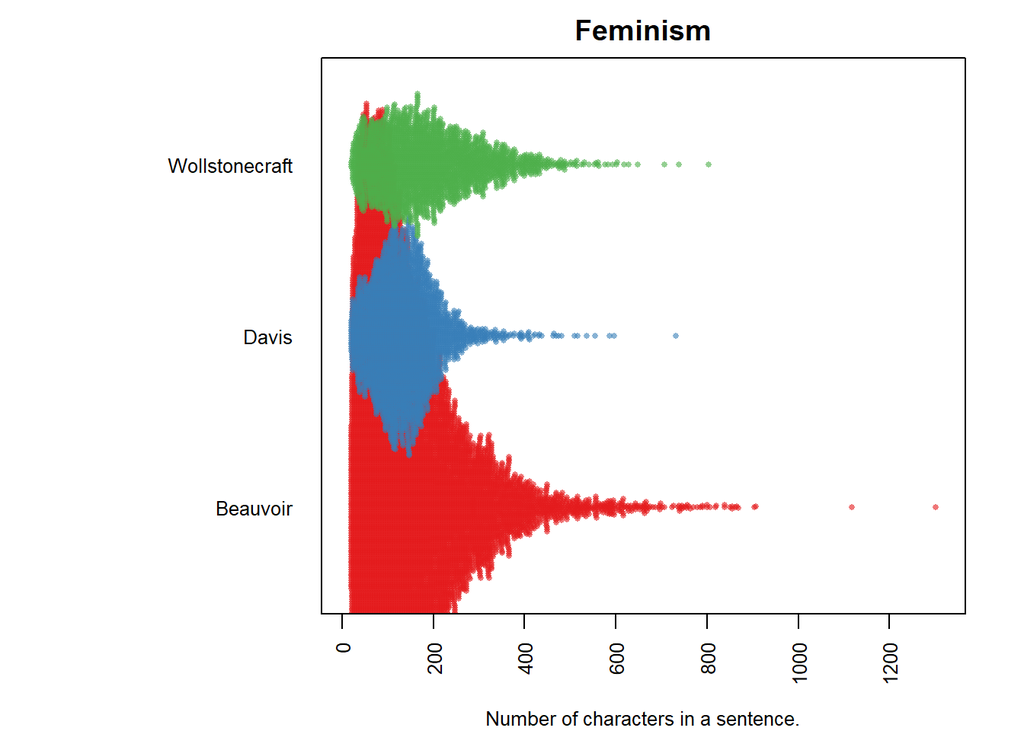

```
## [1] "Wollstonecraft"
## [1] "is injurious to its moral character."
## [2] "or if we worship a God, is not that God a devil?"
## [3] "Verily misery in its most hideous shape."
## [4] "or if we worship a God, is not that God a devil?"
## [5] "They do not cure for the love of God, but money."
## [6] "Verily misery in its most hideous shape."
## [7] "virtue, thou art not an empty name!"
## [8] "It is a solemn truth with respect to God."
##
## [1] "Beauvoir"
## [1] "She attributes all criticism to jealousy or spite."
## [2] "The false hero, to convince himself"
## [3] "Evil is an absolute reality; and flesh is sin."
## [4] "And it is the warning of his death."
## [5] "Love is found in unexpected places.'"
## [6] "She is the cruel mother who tries to kill Snow White."
## [7] "It was good for you to teach him desire."
## [8] "She is happy she wants a divorce and calls on an attorney."
##
## [1] "Davis"
## [1] "percent of lynch victims were accused of rape and."
## [2] "Only the urgent need for money makes them submit to this routine daily."
## [3] "The lie has lost its ability to deceive."
## [4] "percent of lynch victims were accused of rape and."
## [5] "and she cried with surprise and happiness."
## [6] "The lie has lost its ability to deceive."
## [7] "Given the racial composition of the larger Women's Liberation movement, this was not at all surprising."
## [8] "white support for the cause of Black equality in general began to wane."
```

```
## [1] "Wollstonecraft"
```

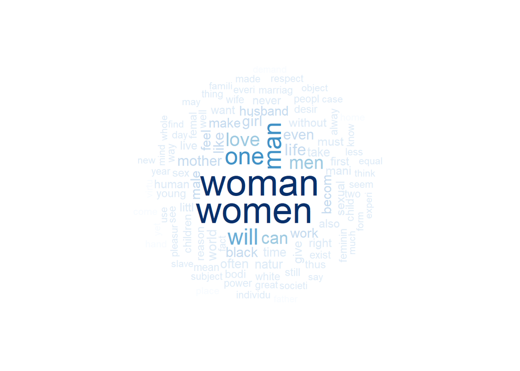

```
## [1] "Beauvoir"
```

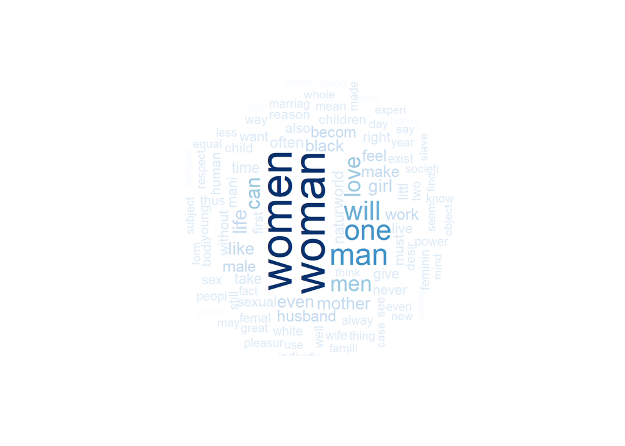

```
## [1] "Davis"
```

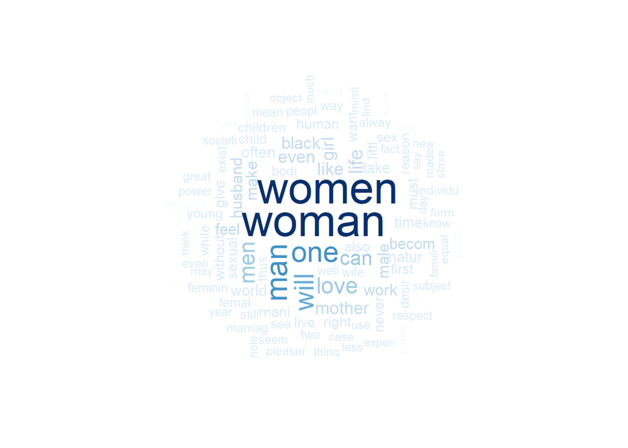

# Analytic Philosophy

| author | first_writing_year |
| --- | --- |
| Moore | 1910 |
| Russell | 1912 |
| Wittgenstein | 1921 |
| Quine | 1950 |
| Popper | 1959 |
| Kripke | 1972 |
| Lewis | 1985 |

Analytic Philosophy was quite interesting to dive into in this data set as it had many contributors to the field. Again, the thinkers here were a little divided by region and era, though Moore would have started the movement with Russell and end up meeting some of the others, like Wittgenstein, but that is to be expected as this is one of the most modern and developing schools of thought. Piece by piece, they built a framework that had a consistent language, a rigorous scientific process, and a novel set of meta-ethics and metaphysics. Still, while the way each thinker contributed to the field was slightly different, they were all of the same predisposition when it came to their logical and scientific approaches.

Below described the complexity of the works and writings of these thinkers. From the beeswarm, there does not seem to be one glaring differentiation, which makes sense as they are all equally highly trained academic researchers. One thing that does stand out to me, however, is the some of the distributions are quite fat at the lower numbers, which shows me that these thinkers shared an affinity for making precise and succinct points, as opposed to rambling on as a conventional academic. It is interest that even from this aspect, the similarities can already be seen.

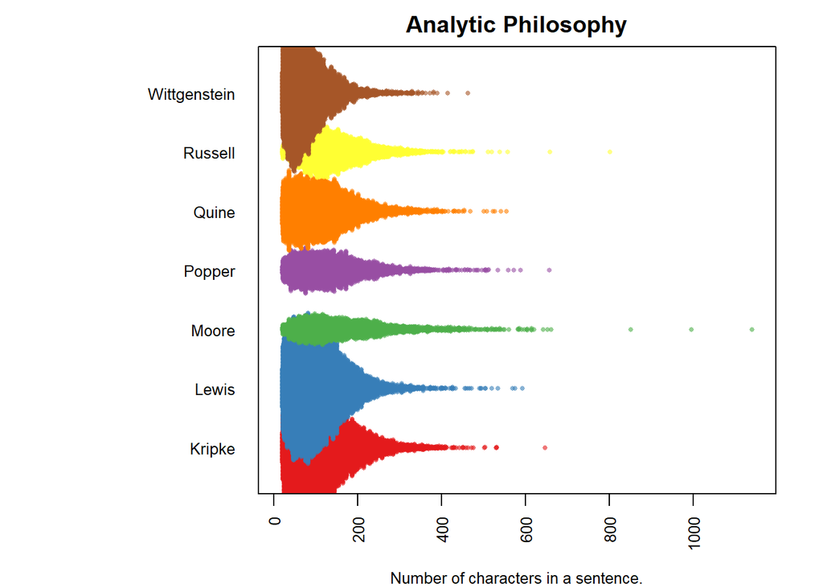

The following highlights the incremental progress on the logical path that these philosophers choose to follow. With following statements and word clouds generated similarly to those from the previous section, there are some interesting takeaways here as well. They all made their separate contribution to the field, however, I can not help but notice how personal these statements are. The most emotional statements are anecdotes and personal words of wisdom, while the rest of the writings are analytical, logical statements. The word clouds are very useful for determining that. As can be seen, words like “one”, “can”, “mean”, “case” all sound the theorizing and musings of one on a logical train of thought. The similar phrasings, word usage, and tone highlight the connections found by those not necessarily congregating mostly.

```
## [1] "Moore"
## [1] "but I do not wish to argue about the meaning of words."
## [2] ", I think a good deal would be gained."
## [3] "either our opponent or we must have mistaken bad reasons for good."
## [4] "either our opponent or we must have mistaken bad reasons for good."
## [5] ", I think a good deal would be gained."
## [6] "Or to put it in the corresponding negative form: It is impossible"
## [7] ", I think a good deal would be gained."
## [8] "The facts present themselves as a kind of antinomy:"
##
## [1] "Russell"
## [1] "Rage and fear have been especially studied by Cannon, whose work is of the greatest importance."
## [2] "though by good luck he answered right the first time."
## [3] "Hart, The Psychology of Insanity, ."
## [4] "He takes the case of imagining a fire."
```

[output cut: 54 more lines]

```
## [1] "Moore"
```

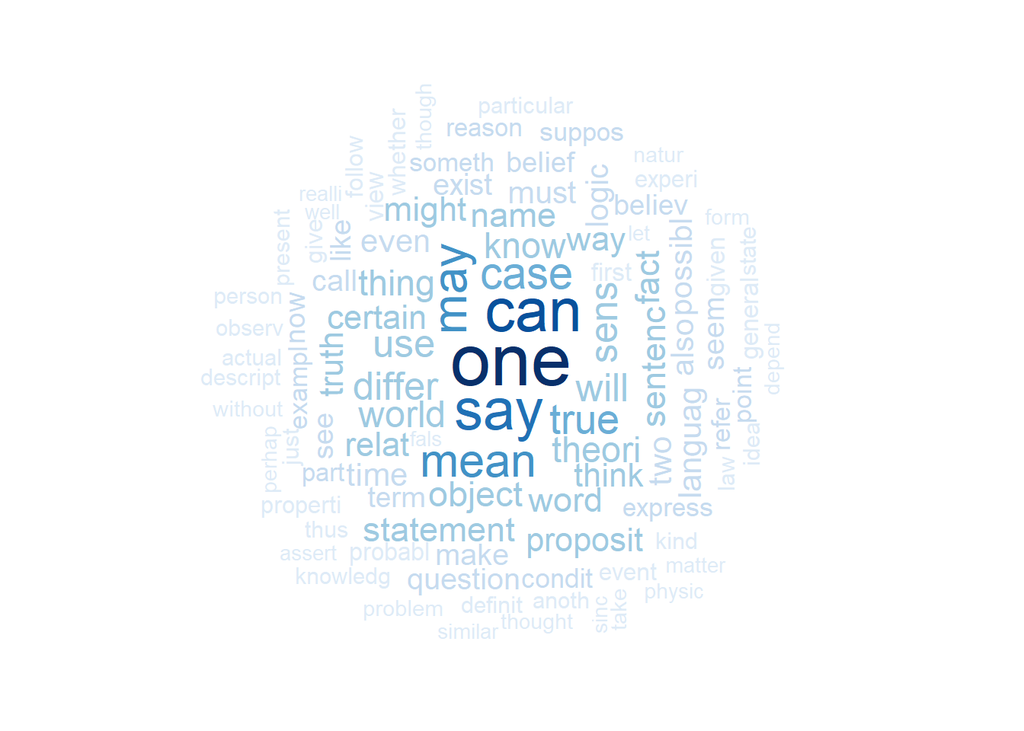

```
## [1] "Russell"
```

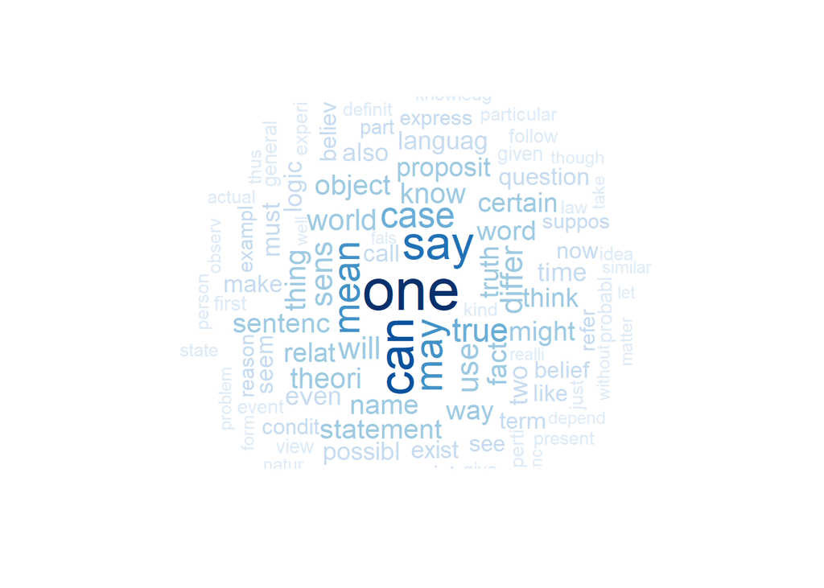

```
## [1] "Wittgenstein"
```

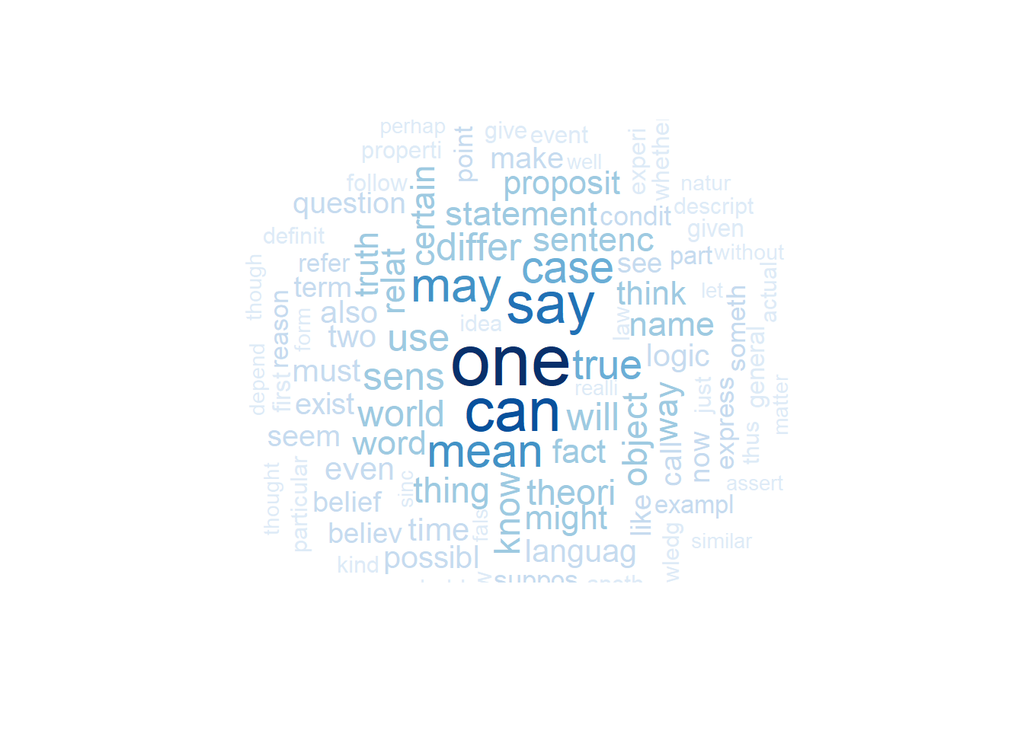

```
## [1] "Quine"
```

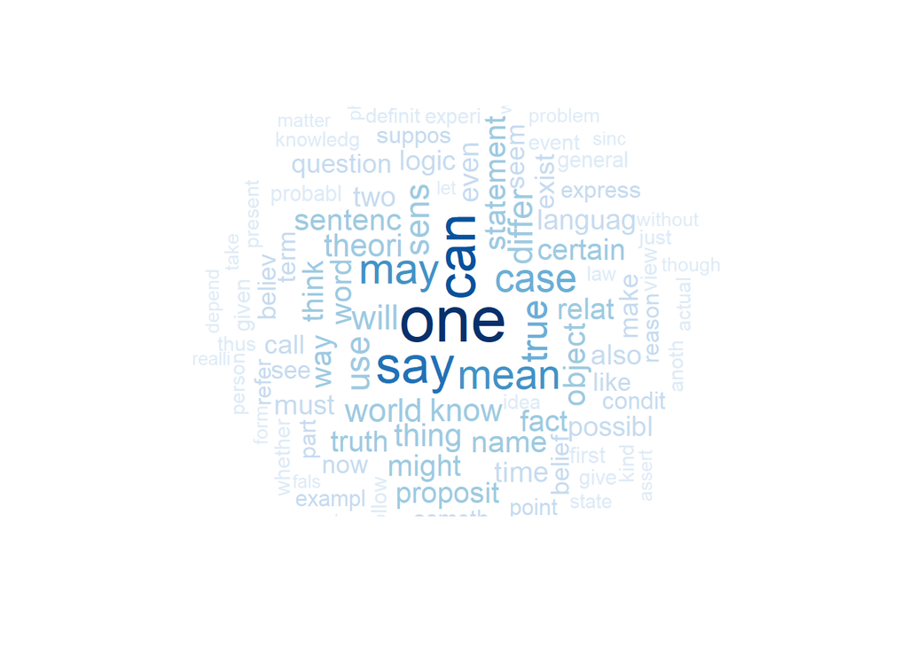

```
## [1] "Popper"
```

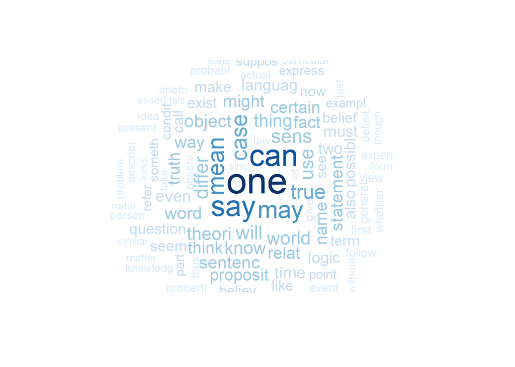

```
## [1] "Kripke"
```

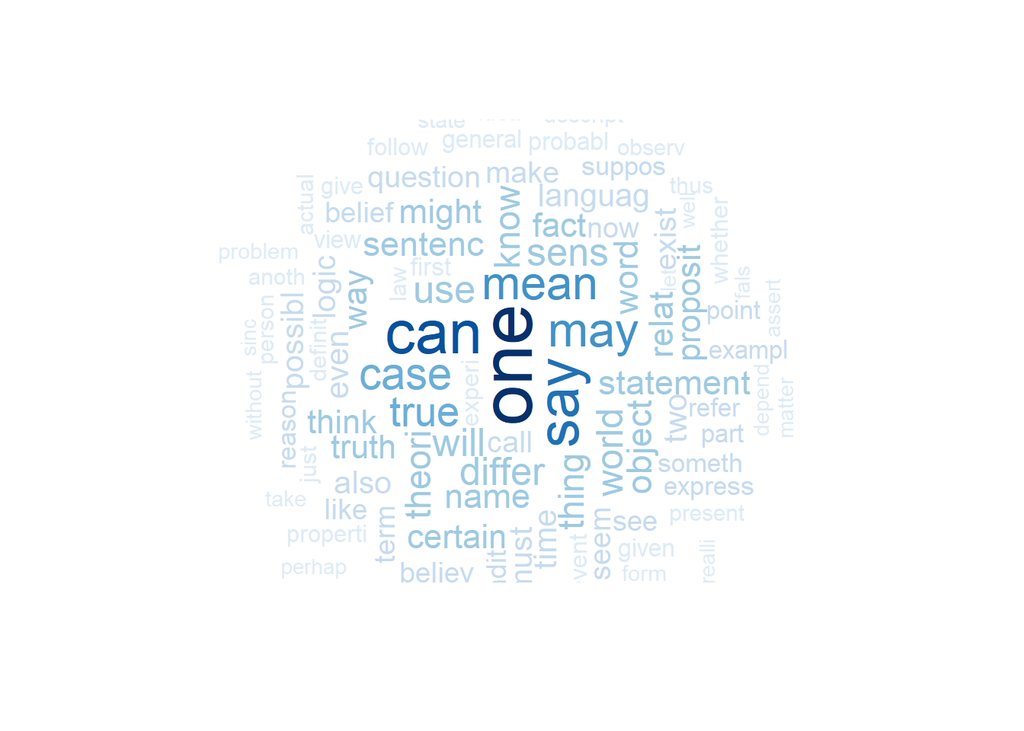

```
## [1] "Lewis"
```

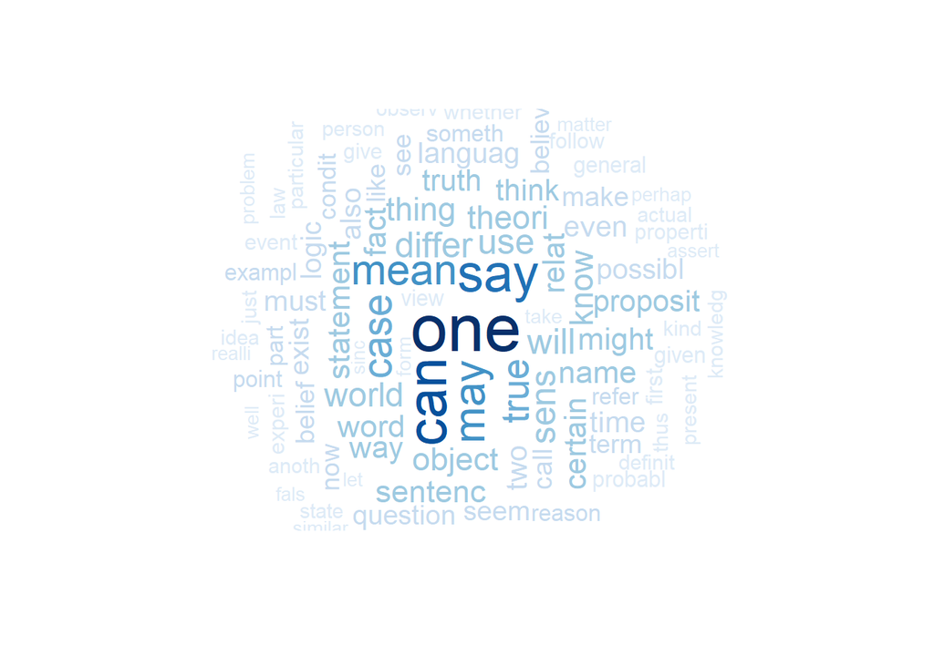

# Conclusion

In the data, we can see similarities that go beyond sharing a belief system. These thinkers that shared a school of thought across the decades also shared experiences, mindsets and values that transcend cultural and physical boundaries. To think that people that lived 150 years ago could share the same beliefs as another is certainly part of the mystifying puzzle that is this world. While it takes some conditions to allow these connections to occur, it is even more dependent on the people thinking and experiencing these lives. These findings show how shared philosophies can spark a movement and connect the shared human experience.